# Data_Organization

Dr. KJG Mazidi

2025-02-02

### Code Accompanying **The Machine Learning Handbooks**, Volume I, Chapter 17

#### Book pdf is available on the GitHub repo: https://github.com/kjmazidi/Machine_Learning

### Introduction

This notebook demonstrates how to use tidyverse methods to manipulate the shape of a data frame:

- separate - divide one column into more than one
- unite - combine multiple columns into one
- gather - gather columns into rows
- spread - spread rows into columns
- arrange - sort rows in the data frame

There are two data wrangling cheat sheets in the GitHub repo. Here we give working examples.

Packages needed in this notebook:

```r
if (!require(tidyverse)){
  install.packages("tidyverse")
}
library("tidyverse")
```

### Preliminary data exploration

We will use the built-in data set *mtcars* to demonstrate a few of these methods, so let’s load it into memory, convert it to a tibble and take a peek at the data.

```r
tb <- as_tibble(mtcars)
glimpse(tb)
```

```
## Rows: 32
## Columns: 11
## $ mpg  <dbl> 21.0, 21.0, 22.8, 21.4, 18.7, 18.1, 14.3, 24.4, 22.8, 19.2, 17.8,…
## $ cyl  <dbl> 6, 6, 4, 6, 8, 6, 8, 4, 4, 6, 6, 8, 8, 8, 8, 8, 8, 4, 4, 4, 4, 8,…
## $ disp <dbl> 160.0, 160.0, 108.0, 258.0, 360.0, 225.0, 360.0, 146.7, 140.8, 16…
## $ hp   <dbl> 110, 110, 93, 110, 175, 105, 245, 62, 95, 123, 123, 180, 180, 180…
## $ drat <dbl> 3.90, 3.90, 3.85, 3.08, 3.15, 2.76, 3.21, 3.69, 3.92, 3.92, 3.92,…
## $ wt   <dbl> 2.620, 2.875, 2.320, 3.215, 3.440, 3.460, 3.570, 3.190, 3.150, 3.…
## $ qsec <dbl> 16.46, 17.02, 18.61, 19.44, 17.02, 20.22, 15.84, 20.00, 22.90, 18…
## $ vs   <dbl> 0, 0, 1, 1, 0, 1, 0, 1, 1, 1, 1, 0, 0, 0, 0, 0, 0, 1, 1, 1, 1, 0,…
## $ am   <dbl> 1, 1, 1, 0, 0, 0, 0, 0, 0, 0, 0, 0, 0, 0, 0, 0, 0, 1, 1, 1, 0, 0,…
## $ gear <dbl> 4, 4, 4, 3, 3, 3, 3, 4, 4, 4, 4, 3, 3, 3, 3, 3, 3, 4, 4, 4, 3, 3,…
## $ carb <dbl> 4, 4, 1, 1, 2, 1, 4, 2, 2, 4, 4, 3, 3, 3, 4, 4, 4, 1, 2, 1, 1, 2,…
```

If we look at the original data, we see that rows had names.

```r
head(mtcars)
```

```
##                    mpg cyl disp  hp drat    wt  qsec vs am gear carb
## Mazda RX4         21.0   6  160 110 3.90 2.620 16.46  0  1    4    4
## Mazda RX4 Wag     21.0   6  160 110 3.90 2.875 17.02  0  1    4    4
## Datsun 710        22.8   4  108  93 3.85 2.320 18.61  1  1    4    1
## Hornet 4 Drive    21.4   6  258 110 3.08 3.215 19.44  1  0    3    1
## Hornet Sportabout 18.7   8  360 175 3.15 3.440 17.02  0  0    3    2
## Valiant           18.1   6  225 105 2.76 3.460 20.22  1  0    3    1
```

It appears that the tidyverse does not like row names, in fact some have commented that row names are evil. Row names are unique identifiers of an observation, which makes sense in this tiny data set. In the larger kinds of data we work with in machine learning, row names do not make sense and therefore the tidyverse dispenses with them. Many older data sets that have row names use integers, which would no longer make sense if we want to sort with arrange() for example.

In this data set, the row names are not just numbers, they identify the car. We are going to convert mtcars to *tb* again, this time converting the row names to a column called *car*.

```r
tb <- rownames_to_column(mtcars, var = "car") %>% as_tibble()
```

### Examine the car column

If we look at the car column we see that most of the cars are in form: make - space - model, except:

- Hornet was made by AMC
- Valiant was made by Chrysler
- Duster was made by Chrysler’s Plymouth
- Camaros were made by Chevrolet which I’m going to call Chevy

Car purists are yelling at me right now for not distinguishing brands of manufacturers, for example Plymoth is a brand of Chrysler, but I can’t hear them, so I’m good. This is an exercise not a search for truth. Plus I don’t even know the difference between Dodge and Chrysler.

By the way, when I met my husband he was driving a beat-up 70s Datsun. I married him anyway.

```r
tb$car # examine the car names
```

```
##  [1] "Mazda RX4"           "Mazda RX4 Wag"       "Datsun 710"
##  [4] "Hornet 4 Drive"      "Hornet Sportabout"   "Valiant"
##  [7] "Duster 360"          "Merc 240D"           "Merc 230"
## [10] "Merc 280"            "Merc 280C"           "Merc 450SE"
## [13] "Merc 450SL"          "Merc 450SLC"         "Cadillac Fleetwood"
## [16] "Lincoln Continental" "Chrysler Imperial"   "Fiat 128"
## [19] "Honda Civic"         "Toyota Corolla"      "Toyota Corona"
## [22] "Dodge Challenger"    "AMC Javelin"         "Camaro Z28"
## [25] "Pontiac Firebird"    "Fiat X1-9"           "Porsche 914-2"
## [28] "Lotus Europa"        "Ford Pantera L"      "Ferrari Dino"
## [31] "Maserati Bora"       "Volvo 142E"
```

So we need to do some editing first before we split the car column into make and model. We could do that with dplyr methods – see **Notebook 17_2 Data Standardization**. We could edit the original data frame (but not the tb) with editData() that can be installed from CRAN, or we could write mtcars to a csv file, edit it by hand, and read that back in. Let’s do that.

```r
# commenting out the write so I don't have to edit again on subsequent notebook runs
#write.csv(mtcars, "mtcars.csv")
```

The write.csv function writes rows names as a column whereas write_csv does not. I want the row names so I choose the dot version.

Now I’m going to read it in and convert it to a tibble one more time.

```r
tb <- read.csv("mtcars.csv") %>% as_tibble()
glimpse(tb)
```

```
## Rows: 32
## Columns: 12
## $ X    <chr> "Mazda RX4", "Mazda RX4 Wag", "Datsun 710", "AMC Hornet 4 Drive",…
## $ mpg  <dbl> 21.0, 21.0, 22.8, 21.4, 18.7, 18.1, 14.3, 24.4, 22.8, 19.2, 17.8,…
## $ cyl  <int> 6, 6, 4, 6, 8, 6, 8, 4, 4, 6, 6, 8, 8, 8, 8, 8, 8, 4, 4, 4, 4, 8,…
## $ disp <dbl> 160.0, 160.0, 108.0, 258.0, 360.0, 225.0, 360.0, 146.7, 140.8, 16…
## $ hp   <int> 110, 110, 93, 110, 175, 105, 245, 62, 95, 123, 123, 180, 180, 180…
## $ drat <dbl> 3.90, 3.90, 3.85, 3.08, 3.15, 2.76, 3.21, 3.69, 3.92, 3.92, 3.92,…
## $ wt   <dbl> 2.620, 2.875, 2.320, 3.215, 3.440, 3.460, 3.570, 3.190, 3.150, 3.…
## $ qsec <dbl> 16.46, 17.02, 18.61, 19.44, 17.02, 20.22, 15.84, 20.00, 22.90, 18…
## $ vs   <int> 0, 0, 1, 1, 0, 1, 0, 1, 1, 1, 1, 0, 0, 0, 0, 0, 0, 1, 1, 1, 1, 0,…
## $ am   <int> 1, 1, 1, 0, 0, 0, 0, 0, 0, 0, 0, 0, 0, 0, 0, 0, 0, 1, 1, 1, 0, 0,…
## $ gear <int> 4, 4, 4, 3, 3, 3, 3, 4, 4, 4, 4, 3, 3, 3, 3, 3, 3, 4, 4, 4, 3, 3,…
## $ carb <int> 4, 4, 1, 1, 2, 1, 4, 2, 2, 4, 4, 3, 3, 3, 4, 4, 4, 1, 2, 1, 1, 2,…
```

Looks good. Notice that there was not a Column Name for the former column of row names, so R chose “X” for me. I’m tempted to change “Merc” to “Mercedes” but I’ll let it go.

### Separate one column into two

In the code below, the separate() method takes column X and separates it into two colums, make and model, getting rid of the X column. The default delimeter is a space, and the extra= parameter told it to just squish everything else in.

```r
tb <-
   tb %>% separate(X, c("make", "model"), extra = "merge")

tb
```

```
## # A tibble: 32 × 13
##    make  model   mpg   cyl  disp    hp  drat    wt  qsec    vs    am  gear  carb
##    <chr> <chr> <dbl> <int> <dbl> <int> <dbl> <dbl> <dbl> <int> <int> <int> <int>
##  1 Mazda RX4    21       6  160    110  3.9   2.62  16.5     0     1     4     4
##  2 Mazda RX4 …  21       6  160    110  3.9   2.88  17.0     0     1     4     4
##  3 Dats… 710    22.8     4  108     93  3.85  2.32  18.6     1     1     4     1
##  4 AMC   Horn…  21.4     6  258    110  3.08  3.22  19.4     1     0     3     1
##  5 AMC   Horn…  18.7     8  360    175  3.15  3.44  17.0     0     0     3     2
##  6 Chry… Vali…  18.1     6  225    105  2.76  3.46  20.2     1     0     3     1
##  7 Plym… Dust…  14.3     8  360    245  3.21  3.57  15.8     0     0     3     4
##  8 Merc  240D   24.4     4  147.    62  3.69  3.19  20       1     0     4     2
##  9 Merc  230    22.8     4  141.    95  3.92  3.15  22.9     1     0     4     2
## 10 Merc  280    19.2     6  168.   123  3.92  3.44  18.3     1     0     4     4
## # ℹ 22 more rows
```

The documentation for separate() says that it will be superceded in favour of separate_wider_position() and separate_wider_delim() because the two functions make the two uses more obvious, the API is more polished, and the handling of problems is better. Superseded functions will not go away, but will only receive critical bug fixes. I’m not really a fan of these long method names, but ok.

### Unite multiple columns into one

Just to show we can, let’s merge make and model back into car.

```r
tb_cars <- tb %>%
  unite("car", make:model)
tb_cars
```

```
## # A tibble: 32 × 12
##    car           mpg   cyl  disp    hp  drat    wt  qsec    vs    am  gear  carb
##    <chr>       <dbl> <int> <dbl> <int> <dbl> <dbl> <dbl> <int> <int> <int> <int>
##  1 Mazda_RX4    21       6  160    110  3.9   2.62  16.5     0     1     4     4
##  2 Mazda_RX4 …  21       6  160    110  3.9   2.88  17.0     0     1     4     4
##  3 Datsun_710   22.8     4  108     93  3.85  2.32  18.6     1     1     4     1
##  4 AMC_Hornet…  21.4     6  258    110  3.08  3.22  19.4     1     0     3     1
##  5 AMC_Hornet…  18.7     8  360    175  3.15  3.44  17.0     0     0     3     2
##  6 Chrysler_V…  18.1     6  225    105  2.76  3.46  20.2     1     0     3     1
##  7 Plymouth_D…  14.3     8  360    245  3.21  3.57  15.8     0     0     3     4
##  8 Merc_240D    24.4     4  147.    62  3.69  3.19  20       1     0     4     2
##  9 Merc_230     22.8     4  141.    95  3.92  3.15  22.9     1     0     4     2
## 10 Merc_280     19.2     6  168.   123  3.92  3.44  18.3     1     0     4     4
## # ℹ 22 more rows
```

That seemed straightforward, the new *car* column replaced columns *make* through *model*.

### select columns

Let’s say we want to work with just the first few columns. Then we want to plot mpg by number of cylinders which we make a factor on the fly. For such a small data set, it is not worth subsetting to make the plot, but if you had a huge data set with hundereds of columns, smaller will be faster.

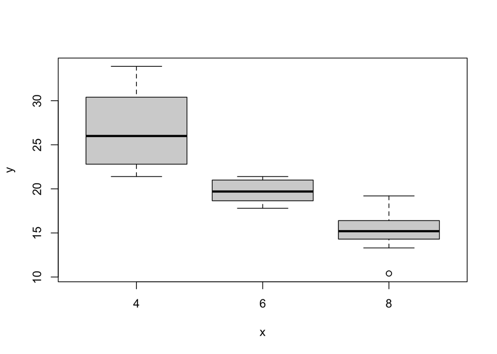

```r
tb_temp <- tb_cars %>% select(car, mpg, cyl)
plot(factor(tb_temp$cyl), tb_temp$mpg)
```

### Gather and spread

For gather and spread, I’m making up a random tibble. The form of this data is not ready for analysis because it would be hard to pick out results by year for example. The data is

```r
performance <- tibble(
  #Team = sample(1:4,10, replace=T),
  Year = 2000:2009,
  Q1 = sample(10:200, 10, replace=T),
  Q2 = sample(10:300, 10, replace=T),
  Q3 = sample(10:400, 10, replace=T),
  Q4 = sample(10:500, 10, replace=T)
)

performance
```

```
## # A tibble: 10 × 5
##     Year    Q1    Q2    Q3    Q4
##    <int> <int> <int> <int> <int>
##  1  2000   146    22    30   235
##  2  2001    75   258   292   437
##  3  2002    37   258   279   247
##  4  2003    27   277   240   338
##  5  2004    95   186   164   480
##  6  2005   197   183    99    35
##  7  2006    60   260   293   420
##  8  2007    14    73    28   468
##  9  2008    14   220   164   193
## 10  2009    19    38   200    60
```

The data above is considered *wide* because each value is in a Quarter variable instead of in a Performance variable. We’ll just let *Performance* be some metric, it doesn’t matter for our purposes.

The gather() method will create two new columns, Quarter and Performance, and put each value in Q1 through Q4 in its own row.

```r
tb_long <- performance %>% gather(Quarter, Performance, Q1:Q4)
glimpse(tb_long)
```

```
## Rows: 40
## Columns: 3
## $ Year        <int> 2000, 2001, 2002, 2003, 2004, 2005, 2006, 2007, 2008, 2009…
## $ Quarter     <chr> "Q1", "Q1", "Q1", "Q1", "Q1", "Q1", "Q1", "Q1", "Q1", "Q1"…
## $ Performance <int> 146, 75, 37, 27, 95, 197, 60, 14, 14, 19, 22, 258, 258, 27…
```

Now that Quarter is its own variable we could do more analysis. This plot shows how performance varied by quarter over the last 10 years. It would have been problematic to pull that intelligence out of the original performance data.

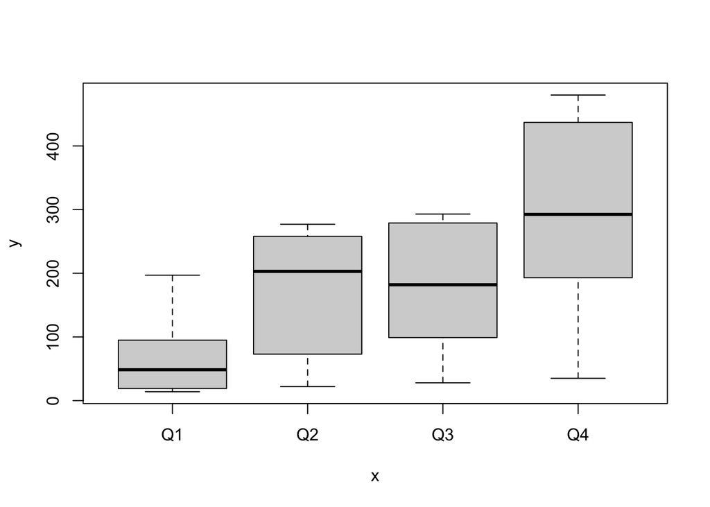

```r
tb_long$Quarter <- as.factor(tb_long$Quarter)
plot(tb_long$Quarter, tb_long$Performance)
```

Now the data is long, 40x3, but what if we want it wide?

```r
tb_wide <- tb_long %>% spread(Quarter, Performance)
glimpse(tb_wide)
```

```
## Rows: 10
## Columns: 5
## $ Year <int> 2000, 2001, 2002, 2003, 2004, 2005, 2006, 2007, 2008, 2009
## $ Q1   <int> 146, 75, 37, 27, 95, 197, 60, 14, 14, 19
## $ Q2   <int> 22, 258, 258, 277, 186, 183, 260, 73, 220, 38
## $ Q3   <int> 30, 292, 279, 240, 164, 99, 293, 28, 164, 200
## $ Q4   <int> 235, 437, 247, 338, 480, 35, 420, 468, 193, 60
```

Now we could see Q4 results across the years. The numbers are all over the place because of the random way the data was created, but in the real world, there would probably be a discernable pattern.

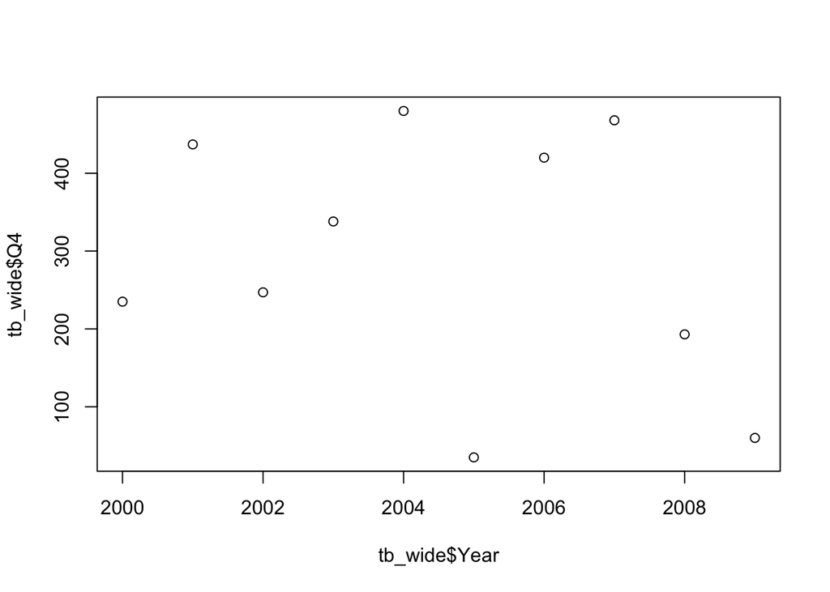

```r
plot(tb_wide$Year, tb_wide$Q4)
```

### arrange

Let’s take the original performance data and play around with arrange(), which orders rows by values in columns.

First, what does performance look like?

```r
performance
```

```
## # A tibble: 10 × 5
##     Year    Q1    Q2    Q3    Q4
##    <int> <int> <int> <int> <int>
##  1  2000   146    22    30   235
##  2  2001    75   258   292   437
##  3  2002    37   258   279   247
##  4  2003    27   277   240   338
##  5  2004    95   186   164   480
##  6  2005   197   183    99    35
##  7  2006    60   260   293   420
##  8  2007    14    73    28   468
##  9  2008    14   220   164   193
## 10  2009    19    38   200    60
```

For example, let’s order Q1 from low to high over the years.

```r
arrange(performance, Q1)
```

```
## # A tibble: 10 × 5
##     Year    Q1    Q2    Q3    Q4
##    <int> <int> <int> <int> <int>
##  1  2007    14    73    28   468
##  2  2008    14   220   164   193
##  3  2009    19    38   200    60
##  4  2003    27   277   240   338
##  5  2002    37   258   279   247
##  6  2006    60   260   293   420
##  7  2001    75   258   292   437
##  8  2004    95   186   164   480
##  9  2000   146    22    30   235
## 10  2005   197   183    99    35
```

### Final thoughts

For a nicely written, comprehensive dplyr tutorial, see Brad Boehmke’s tutorial:

https://rpubs.com/bradleyboehmke/data_wrangling